# The Importance of a First Impression: An Exploration of Chess

### By: Rithik Sebastian

[figure not shown]

## Motivation

Chess is without a doubt one of the most well known games, if not the most well known game in the world. The earliest recorded text about chess dates back to the 7th century. The modern version of chess that most people know emerged from Southern Europe in the late 15th century. What this means is that the current version of chess that we play has been around for over 500 years! Moreover, there are many new people who begin playing chess every day!

However, what's unfortunate for these new players is that there are over 600 million adults who play chess regularly (according to Chess.com). If there are so many people that have more experience than them, how are these new players supposed to get better? That's where the rating system comes in. No matter where you play chess, whether it be online or in person, you will use a rating system for any rated chess match. The most common of these rating systems is the ELO rating system, which is used by FIDE (World Chess Federation). What this system does is give every player a number, which is called their rating. When facing opponents that have a higher rating than you, you gain a lot of rating points by winning and lose little when you are beaten. The inverse occurs when facing opponents with a lower rating than you. What this does is slowly, but surely, shift your rating to a place that truly represents your skill level. What most chess websites and tournaments do is place players against other players with similar ratings.

While this system is great in that a new player will eventually get to place where they are comfortable in, starting off can be very intimidating. Since all new players are given an arbitrary starting rating (it differs by the system), it's very possible that a new player will have to play against players who are much more skilled than they are and be discouraged from playing the game.

What I want to do through this Data Science tutorial is help give these new players a leg up in their first couple of matches. To do this, I am going to explore just how important the first move of the match is. Any chess player will tell you that learning certain openings to a game will help you fare better, but for players who are brand new to the game, it will be hard for them to grasp how to do these openings (especially since each opening has variants based on your opponents' moves). As such, finding out how well the first move of the match affects the outcome of a game through this tutorial then simply reacting to your opponent's moves will be the best strategy for these beginners.

## Setting Up

Before we can even start doing any work with our data, we must first do a setup. Specifically, we will be importing a few libraries that will our analysis. These libraries are:

- pandas, a library that uses a type of table called DataFrames which will be useful in our analysis
- numpy, a library that will be useful for mathematical calculations
- re, a library that will be used for regular expressions
- matplotlib, a library that will be used for plotting
- sklearn, a library that will be used for regression analysis
- scipy, another library that will be used for regression analysis

```python
import pandas as pd
import numpy as np
import re
import matplotlib.pyplot as plt
from sklearn import linear_model
from sklearn import preprocessing
from scipy import stats
```

## Data Collection

Now that we've added all of our libraries, we now need to get all of our data. The dataset that we will be using for this tutorial will consist of multiple chess matches over the span of a month. I obtained this dataset from the online chess website lichess.org through another website, [Kaggle](https://www.kaggle.com/ironicninja/online-chess-games), where the data was put into a format that I could use here. Lichess is one of most popular chess websites in the world. In addition to this, Lichess publishes all of the data from every chess match that is played on their website on a monthly basis. This serves us greatly because it gives real data about how players play at different rankings. For this exploration, we will be using the chess data from August 2014. This is purely due to the fact that the data for more recent months takes up too much space for us to be able to do this exploration quickly and effectively.

```python
# Collecting the data from our csv file
chess_data = pd.read_csv("lichess-08-2014.csv")
chess_data.head()
```

|  | Unnamed: 0 | PGN | Mode | Result | Average Rating | Rating Difference | Termination Type |
| --- | --- | --- | --- | --- | --- | --- | --- |
| 0 | 0 | 1. e4 g6 2. d4 Bg7 3. c3 d6 4. Qf3 Nf6 5. h3 O... | Classical | Black Wins | 1538 | -262 | Time forfeit |
| 1 | 1 | 1. d4 Nf6 2. c4 g6 3. a3 Bg7 4. Nf3 O-O 5. Nc3... | Blitz | Black Wins | 1492 | -220 | Time forfeit |
| 2 | 2 | 1. e4 c5 2. Qf3 e5 3. Bc4 Nf6 4. Nh3 h6 5. g4 ... | Blitz | White Wins | 1413 | 213 | Normal |
| 3 | 3 | 1. e4 e5 2. Nf3 d6 3. Nc3 f5 4. exf5 Bxf5 5. d... | Blitz | Black Wins | 1444 | -358 | Normal |
| 4 | 4 | 1. e4 e6 2. d4 d5 3. Nc3 Nf6 4. e5 Ne4 5. Nce2... | Bullet | White Wins | 1931 | 117 | Normal |

## Data Tidying

This is great! Now we have a pandas DataFrame with hundreds of thousands of chess matches. However, there is a lot of data here that we won't be needing and/or need to change. This data tidying will allow us to not waste space on information we don't need.

```python
# Removing unnecessary columns
chess_data = chess_data.drop(columns = ["Unnamed: 0","Termination Type"])
```

```python
chess_data.head()
```

|  | PGN | Mode | Result | Average Rating | Rating Difference |
| --- | --- | --- | --- | --- | --- |
| 0 | 1. e4 g6 2. d4 Bg7 3. c3 d6 4. Qf3 Nf6 5. h3 O... | Classical | Black Wins | 1538 | -262 |
| 1 | 1. d4 Nf6 2. c4 g6 3. a3 Bg7 4. Nf3 O-O 5. Nc3... | Blitz | Black Wins | 1492 | -220 |
| 2 | 1. e4 c5 2. Qf3 e5 3. Bc4 Nf6 4. Nh3 h6 5. g4 ... | Blitz | White Wins | 1413 | 213 |
| 3 | 1. e4 e5 2. Nf3 d6 3. Nc3 f5 4. exf5 Bxf5 5. d... | Blitz | Black Wins | 1444 | -358 |
| 4 | 1. e4 e6 2. d4 d5 3. Nc3 Nf6 4. e5 Ne4 5. Nce2... | Bullet | White Wins | 1931 | 117 |

The first thing we've done here is remove the columns that we don't need any information from. These columns were the "Unnamed: 0" and "Termination Type" columns. The "Unnamed: 0" column was no more than a duplicate of the indices so they could be removed. The "Termination Type" column won't concern us for this exploration as we are solely looking at the result of each match, not at why they ended.

Now that we've removed some of the data we don't need, we can now modify the remaining data into a format that will be useful for us.

```python
# Given the list of moves in chess notation, this function will compute the first move and return that value
def move1(movelist):
    move = re.search('^1\. (N?[a-h][34])', movelist)
    if move:
        return move.group(1)
    else:
        # returns NaN if there's an problem in the data
        return np.NaN
```

```python
# Given the result of the match, this function returns the number of points (0 for a loss, 0.5 for a tie, 1 for a win)
def result_to_num(result):
    if (result == "Black Wins"):
        return 0
    elif (result == "White Wins"):
        return 1
    elif (result == "Draw"):
        return 0.5
    else:
        # Returns NaN if given an unexpected value
        return np.NaN
```

```python
# Creates new columns using the recently defined function
chess_data["Move 1"] = chess_data["PGN"].map(lambda moves: move1(moves))
chess_data["Result Points"] = chess_data["Result"].map(lambda res: result_to_num(res))
chess_data["White Rating"] = chess_data["Average Rating"] + chess_data["Rating Difference"]/2

# Removes any rows where the match was a correspondence game
chess_data = chess_data[chess_data["Mode"] != "Correspondence"].reset_index().drop(columns = "index")
```

Now that we've modified our data to our liking, we can drop the old columns that we'll no longer need.

```python
# Drops remaining unneeded columns and any rows with missing data
chess_data = chess_data.drop(columns = ["PGN", "Result", "Average Rating", "Mode"])
chess_data = chess_data.dropna()

# Reorder columns
chess_data = chess_data[["White Rating", "Rating Difference", "Move 1", "Result Points"]]
```

```python
chess_data.head()
```

|  | White Rating | Rating Difference | Move 1 | Result Points |
| --- | --- | --- | --- | --- |
| 0 | 1407.0 | -262 | e4 | 0.0 |
| 1 | 1382.0 | -220 | d4 | 0.0 |
| 2 | 1519.5 | 213 | e4 | 1.0 |
| 3 | 1265.0 | -358 | e4 | 0.0 |
| 4 | 1989.5 | 117 | e4 | 1.0 |

## Exploratory Analysis/Visualization

Now that we have a table we're comfortable with, let's start to do some visualization and analysis. First, let's look at what the competition looks like for our new player. To do that, we'll make a scatter plot to visualize the Rating Difference between players at different ratings for white.

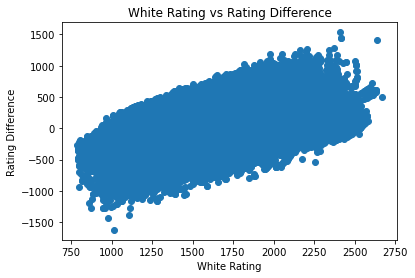

```python
# Plots data and labels appropriate axes
plt.scatter(chess_data["White Rating"], chess_data["Rating Difference"])
plt.title('White Rating vs Rating Difference')
plt.xlabel('White Rating')
plt.ylabel('Rating Difference')
plt.show()
```

There are a lot of points to use, so we can observe a pretty clear trend in this data. It seems as though when the rating of the white player increases, the difference in rating for matches increases at a linear rate. This makes sense intuitively since there are only so many high ranked players for other high ranked players to play against. Since this plot seems to be linear, let's attempt to place a linear regression onto it.

```python
# Obtaining the x and y points
x = chess_data["White Rating"].to_numpy().flatten()
y = chess_data["Rating Difference"].to_numpy().flatten()

# Obtaining the regression and its slope and intercept (m and b)
lm = linear_model.LinearRegression()
lm.fit(x.reshape(-1,1),y)
m = lm.coef_[0]
b = lm.intercept_
```

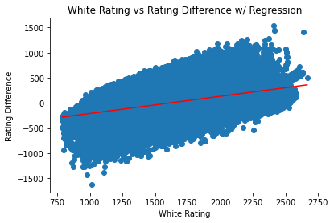

```python
# Plots data and labels appropriate axes
plt.scatter(chess_data["White Rating"], chess_data["Rating Difference"])
plt.title('White Rating vs Rating Difference w/ Regression')
plt.xlabel('White Rating')
plt.ylabel('Rating Difference')

# Plots the linear regression
linreg_x = np.linspace(min(x),max(x),2)
linreg_y = m*linreg_x + b
plt.plot(linreg_x, linreg_y, color = 'red')

plt.show()
```

Now we have a linear regression for this set! With this, we can predict how tough the opponents will be for our new chess player. Since on lichess, all new players start with a ranking of 1500, we will use our regression to predict the Rating Difference at a White Ranking of 1500.

```python
# Uses regression to estimate initial difference in rating
start_difference = lm.predict([[1500]])[0]
start_difference
```

```
-38.74760624568398
```

This is concerning. According to our regression, a new player is, on average, going to be at a disadvantage of about 39 ranking points. Now before any new chess players start to panic, let's observe just how much this difference in ranking will matter. We'll do this by creating a scatter plot of Rating Difference vs Result Points and looking for any relationship.

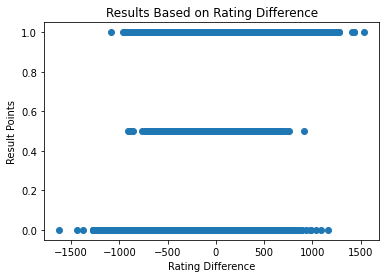

```python
# Plots data and labels appropriate axes
plt.scatter(chess_data["Rating Difference"], chess_data["Result Points"])
plt.title('Results Based on Rating Difference')
plt.xlabel('Rating Difference')
plt.ylabel('Result Points')
plt.show()
```

Admittedly, while this plot does give some information, it's not very useful. This is due to the fact that as of right now, there are only 3 possible values for Result Points. However, since there are likely multiple matches at each Rating Difference, we can actually take an average of the Result Points at each Rating Difference and make a new plot with this result.

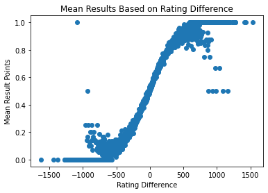

```python
# Averages the results at each rating difference
mean_results_by_rating_diff = chess_data.groupby(["Rating Difference"]).mean().reset_index()

# Plots data and labels appropriate axes
plt.scatter(mean_results_by_rating_diff["Rating Difference"], mean_results_by_rating_diff["Result Points"])
plt.title('Mean Results Based on Rating Difference')
plt.xlabel('Rating Difference')
plt.ylabel('Mean Result Points')
plt.show()
```

This plot is a lot better, as it actually gives us an idea of how the rating difference affects the result of a game. There are a few sporadic points, but this is likely due to lack of data, which could be solved by getting data from a month with more matches in it. Nevertheless, our plot seems to very clearly have a logistic trend. As such, we can attempt to fit a logistic regression to it.

```python
# Creating a logistic regression
lr = linear_model.LogisticRegression()
le = preprocessing.LabelEncoder()

# Obtaining x and y values
x = chess_data["Rating Difference"].to_numpy().flatten()
y = chess_data["Result Points"].to_numpy().flatten()

# Using the label encoder to convert continuous data into categorical data
le.fit(y)

# Fitting the logistic regression
lr.fit(x.reshape(-1,1), le.transform(y))
```

```
LogisticRegression()
```

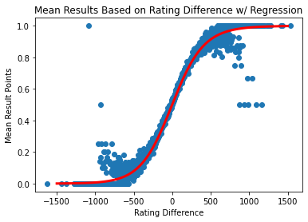

```python
# Plots data
plt.scatter(mean_results_by_rating_diff["Rating Difference"], mean_results_by_rating_diff["Result Points"])

# Plots logistic regression
X_test = np.linspace(-1500, 1500, 300)
Y_test = lr.predict_proba(X_test.reshape(-1,1))[:,2]
plt.plot(X_test, Y_test, color='red', linewidth=3)

# Labels appropriate axes
plt.title('Mean Results Based on Rating Difference w/ Regression')
plt.xlabel('Rating Difference')
plt.ylabel('Mean Result Points')
plt.show()
```

Now we have a logistic regression for this set! With this, we can predict how likely our new chess player is to win at different rating differences. Since we've determined that our new chess player will most likely be at a ranking deficit of about 39 ranking points, we will use our regression to predict our player's chances of winning with said deficit.

```python
# Uses logistic regression to calculate initial probabilities of losing, drawing, and winning
start_chance = lr.predict_proba([[start_difference]])[0]
start_chance
```

```
array([0.50540631, 0.03978578, 0.45480791])
```

This isn't actually that bad! We knew that our new chess player would be at a disadvantage, but what this prediction tells us is that the odds of our new player winning their first match is 45.5%, only slightly less likely than a coin flip. With all of this in mind, since we know that a win is very possible for our new player, we can now explore the impact of the first move.

## Hypothesis Testing

For this section, we are going to use some hypothesis testing to see how important the first move of a chess match is. But before this, we want to see if white's rating also has an impact.

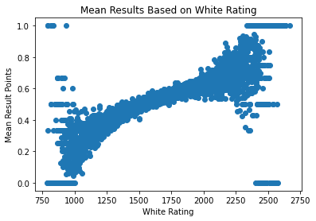

```python
# Finds average result points at each rating
mean_results_by_rating = chess_data.groupby(["White Rating"]).mean().reset_index()

# Plots data and labels appropriate axes
plt.scatter(mean_results_by_rating["White Rating"], mean_results_by_rating["Result Points"])
plt.title('Mean Results Based on White Rating')
plt.xlabel('White Rating')
plt.ylabel('Mean Result Points')
plt.show()
```

From this, we can quite clearly see that there is some relationship between white's rating and likelihood of winning. However, this includes all possible first moves. Let's now observe the average win rate for each possible first move.

```python
# Creates list of all possible first moves
first_moves = np.unique(chess_data["Move 1"].values)

# Prints average win rate for each possible first move
for move in first_moves[1:]:
    print(move + ": " + str(np.mean(chess_data[chess_data["Move 1"] == move]["Result Points"])))
```

```
Nc3: 0.4983922829581994
Nf3: 0.5310537060301508
Nh3: 0.3312883435582822
a3: 0.4328263624841572
a4: 0.42487046632124353
b3: 0.5203712780296532
b4: 0.5219425261750946
c3: 0.44143763213530657
c4: 0.5117666556181637
d3: 0.47350194144191415
d4: 0.5363464972738943
e3: 0.4587746750120366
e4: 0.526554880710375
f3: 0.42129918800749533
f4: 0.5385390669994241
g3: 0.5206270190118095
g4: 0.5997442455242967
h3: 0.3931888544891641
h4: 0.42916352675207237
```

As one can see, the win rates here are quite varying. From as low as 33% to as high as 60%. Since this could impact the graph of white rating vs. rating points, let's split the data by first move and observe how this changes the relationship.

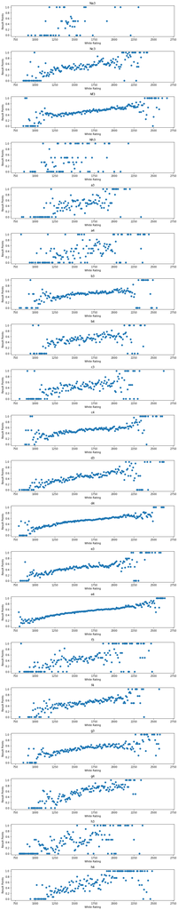

```python
# Rounds all white ratings to the nearest ten for visualization purposes
chess_data["White Rating"] = chess_data["White Rating"].map(lambda rating: np.round(rating,-1))

# Creating the subplots
fig, axes = plt.subplots(20,1, figsize=(10,50), sharey=True, sharex = True)
for i in range(len(axes)):
    # Obtaining all matches with the appropriate first move
    curr = chess_data[chess_data["Move 1"] == first_moves[i]].groupby("White Rating").mean().reset_index()

    # Obtaining the x and y points
    x = curr["White Rating"].to_numpy().flatten()
    y = curr["Result Points"].to_numpy().flatten()

    # Plotting the scatter plot, then labelling all of the axes
    axes[i].scatter(x,y)
    axes[i].set_title(first_moves[i])
    axes[i].set_ylabel("Result Points")
    axes[i].tick_params(axis='both', which='both', labelsize=10, labelbottom=True)
    axes[i].set_xlabel("White Rating")
fig.tight_layout()
```

This is interesting because we can that where before, the graph of White Rating vs. Result Points seemed akin a tangent curve, these graphs seem almost linear. Here is where we can do our hypothesis test.

To see if these relationships are linear, we will make our null hypothesis for each move that there is no linear relationship between white's rating and the average result points and our alternative hypothesis that there is some linear relationship between white's rating and the average result points. Another way of saying this is that the null hypothesis is that the slope of a regression line between white's rating and the average result points is 0 and our alternative hypothesis is that the slope of a regression line between white's rating and the average result points is not 0.

As such, we can perform our hypothesis test by constructing linear regressions for each first move and observing the p-value (the probability that the slope is what we find assuming that the null hypothesis holds true). If the p-value is lower than our significance level (which I have chosen to be 0.01), we can reject our null hypothesis.

```python
# Prints p value and slope for each first move
print("move\tp value\t\t\tslope")
for move in first_moves:
    curr = chess_data[chess_data["Move 1"] == move].groupby("White Rating").mean().reset_index()
    lm2 = stats.linregress(curr["White Rating"],curr["Result Points"])
    print(move + ":\t" + str(lm2.pvalue) + "\t" + str(lm2.slope))
```

```
move	p value			slope
Na3:	0.002510659398297419	0.0005309106833208916
Nc3:	5.072340335457781e-32	0.0004890384786554998
Nf3:	5.19099479205568e-29	0.000341078591309329
Nh3:	0.0028034624128809612	0.00046894468418191176
a3:	2.666985790290186e-16	0.0006112824960035009
a4:	6.409131176165866e-11	0.0004909695567817142
b3:	4.421222954241724e-10	0.0002347153193774711
b4:	1.184214160450829e-09	0.0003198782596354504
c3:	3.0104612180437378e-12	0.0003550085536193346
c4:	5.149047904132582e-27	0.0003336162823970971
d3:	3.830930573571142e-24	0.0003760649373400578
d4:	7.39124787286508e-71	0.00037425171999498164
e3:	7.745754756217096e-31	0.0003840366593286749
e4:	2.1297262567514964e-96	0.0003799950789620848
f3:	3.1209817980482575e-19	0.00046463750603057704
f4:	5.59725248092485e-33	0.00043383968238191106
g3:	3.3989798140925834e-38	0.0003677791352791872
g4:	3.851566588703713e-42	0.0006473897948868588
h3:	1.1204048696342184e-16	0.0005350560218692219
h4:	3.659388582200992e-27	0.0005854392591495035
```

As we can see from the output above, all of our p values are less than our significance level of 0.01. As such, we can reject the null hypothesis for each first move and say that there is some linear relationship between white's rating and result points. What we can also observe is that the value of the slope for each first move is, in fact, different from each other. While this difference may seem small, we must remember that ratings have rather high values, so the small differences between each slope are magnified as such high magnitudes.

Now seeing that the first move will have an impact on the result points, we will use sklearn's linear regression one last time to determine the best first move for our new player. Before we can make the regression, we will have to add some columns to our table. Since the "Move 1" column contains categorical data, we need to convert it to numerical data in our to incorporate it into our linear regression. To do this, we will create columns for each first move that contain a 1 if a match started with that move or a 0 if it didn't. Since we've determined that there is also a different effect when considering both white's rating and the first move, we will also add interaction columns between white's rating and the first moves.

```python
# Creating new columns for first move and rating*first move parameters
move_cols = pd.get_dummies(chess_data["Move 1"], drop_first=True, prefix='is')
standard_cols = chess_data[["White Rating","Rating Difference","Result Points"]]
combined_tbl = pd.concat([standard_cols, move_cols], axis = 1)

for m in first_moves:
    if (m != "Na3"):
        combined_tbl["rating*" + m] = combined_tbl["White Rating"] * combined_tbl["is_" + m]
```

```python
combined_tbl.head()
```

|  | White Rating | Rating Difference | Result Points | is_Nc3 | is_Nf3 | is_Nh3 | is_a3 | is_a4 | is_b3 | is_b4 | ... | rating*d3 | rating*d4 | rating*e3 | rating*e4 | rating*f3 | rating*f4 | rating*g3 | rating*g4 | rating*h3 | rating*h4 |
| --- | --- | --- | --- | --- | --- | --- | --- | --- | --- | --- | --- | --- | --- | --- | --- | --- | --- | --- | --- | --- | --- |
| 0 | 1410.0 | -262 | 0.0 | 0 | 0 | 0 | 0 | 0 | 0 | 0 | ... | 0.0 | 0.0 | 0.0 | 1410.0 | 0.0 | 0.0 | 0.0 | 0.0 | 0.0 | 0.0 |
| 1 | 1380.0 | -220 | 0.0 | 0 | 0 | 0 | 0 | 0 | 0 | 0 | ... | 0.0 | 1380.0 | 0.0 | 0.0 | 0.0 | 0.0 | 0.0 | 0.0 | 0.0 | 0.0 |
| 2 | 1520.0 | 213 | 1.0 | 0 | 0 | 0 | 0 | 0 | 0 | 0 | ... | 0.0 | 0.0 | 0.0 | 1520.0 | 0.0 | 0.0 | 0.0 | 0.0 | 0.0 | 0.0 |
| 3 | 1260.0 | -358 | 0.0 | 0 | 0 | 0 | 0 | 0 | 0 | 0 | ... | 0.0 | 0.0 | 0.0 | 1260.0 | 0.0 | 0.0 | 0.0 | 0.0 | 0.0 | 0.0 |
| 4 | 1990.0 | 117 | 1.0 | 0 | 0 | 0 | 0 | 0 | 0 | 0 | ... | 0.0 | 0.0 | 0.0 | 1990.0 | 0.0 | 0.0 | 0.0 | 0.0 | 0.0 | 0.0 |

5 rows × 41 columns

With this new table, we can now create our final regression.

```python
# Obtaining the independent and dependent variables and fitting the regression
ind = combined_tbl.drop("Result Points", axis = 1)
dep = combined_tbl["Result Points"]
lm_wmove1 = linear_model.LinearRegression()
lm_wmove1.fit(ind,dep)
```

```
LinearRegression()
```

```python
# Printing all of the coefficients from the regression
for i in range(len(ind.columns)):
    print(ind.columns[i] + ": " + str(lm_wmove1.coef_[i]))
```

```
White Rating: 8.948501212336248e-05
Rating Difference: 0.0009445389288555534
is_Nc3: 0.16428782235980863
is_Nf3: 0.16641932727695097
is_Nh3: 0.3933030254116282
is_a3: -0.014840148927046997
is_a4: -0.10048062148240415
is_b3: 0.14756851557436254
is_b4: 0.21448706653476787
is_c3: 0.09794421145455885
is_c4: 0.18890526913302735
is_d3: 0.1305621565706602
is_d4: 0.1913365601116459
is_e3: 0.1642937168199056
is_e4: 0.1672874064301837
is_f3: -0.013231019654112544
is_f4: 0.22179995935533917
is_g3: 0.14550903767162496
is_g4: 0.04482841143300951
is_h3: 0.027527321686001492
is_h4: 0.17344130168244826
rating*Nc3: -8.744011760376588e-05
rating*Nf3: -9.123365366461344e-05
rating*Nh3: -0.00030001862073089945
rating*a3: -6.578520052903363e-06
rating*a4: 3.981391131415661e-05
rating*b3: -8.110148259945265e-05
rating*b4: -0.000111019016231096
rating*c3: -6.550288723694163e-05
rating*c4: -0.00010953710835865383
rating*d3: -7.979326075532377e-05
rating*d4: -0.00010585575043836932
rating*e3: -0.00010242047623301957
rating*e4: -9.413084633381498e-05
rating*f3: -3.438836692301905e-06
rating*f4: -0.00012381712968469524
rating*g3: -8.00698381425695e-05
rating*g4: -4.7717847028178285e-06
rating*h3: -4.868234811229435e-05
rating*h4: -0.00012362722898372148
```

Our regression is complete! From the output above, we can see the coefficients for each of the columns that were used to make the regression. However, these coefficients won't tell us what the best first move is for our new chess player. To do that, we will need to use our regression to make the win prediction for each first move.

```python
# Given a white rating, a rating difference, and a first move, this function returns an array to feed as
# the prediction for our regression
def predict_format(rating, diff, move):
    if (move in first_moves):
        res = np.zeros(40)
        res[0] = rating
        if (move != "Na3"):
            index = first_moves.tolist().index(move)
            res[index+1] = 1
            res[index+20] = rating
        return [res]
    else:
        return []
```

```python
# Creating a final DataFrame which shows the odds of winning for each first move for our new chess player
move_df = pd.DataFrame()
move_df["Move 1"] = first_moves
move_df["Prediction"] = move_df["Move 1"].map(lambda move: lm_wmove1.predict(predict_format(1500, start_difference, move))[0])
move_df.sort_values(by = "Prediction")
```

|  | Move 1 | Prediction |
| --- | --- | --- |
| 3 | Nh3 | 0.436190 |
| 18 | h3 | 0.447419 |
| 5 | a4 | 0.452156 |
| 4 | a3 | 0.468207 |
| 14 | f3 | 0.474526 |
| 19 | h4 | 0.480916 |
| 8 | c3 | 0.492605 |
| 0 | Na3 | 0.492915 |
| 12 | e3 | 0.503578 |
| 10 | d3 | 0.503788 |
| 9 | c4 | 0.517515 |
| 16 | g3 | 0.518320 |
| 6 | b3 | 0.518832 |
| 13 | e4 | 0.519007 |
| 2 | Nf3 | 0.522484 |
| 11 | d4 | 0.525468 |
| 1 | Nc3 | 0.526043 |
| 15 | f4 | 0.528990 |
| 17 | g4 | 0.530586 |
| 7 | b4 | 0.540874 |

## Conclusion

With this last DataFrame, we can observe that the first move that maximizes our new chess player's chance of winning is b4, while the first move that minimizes our new chess player's chance of winning is Nh3. With a little more external research, we can see why these results make sense. b4 is the opening move of the Sokolsky Opening, which is an uncommon opening and likely an opening that our player's opponent might not be accustomed to. At the same time, Nh3 is a rather bad move as it puts our player's knight (that's what the N stands for) in a rather poor location.

With that, we have completed this tutorial. We have completed the steps of the Data Science Pipeline by

1. Collecting our data
2. Refining it to meet our needs
3. Doing initial visualization and analysis
4. Applying a Hypothesis Test to check for relationships, and
5. Drew a useful conclusion from our results

Thank you for exploring this topic with me and good luck in your next chess match!

## Resources

Below are some resources you may find useful for exploring more about data science and chess:

Data Science:

- [Pandas DataFrames](https://pandas.pydata.org/pandas-docs/stable/user_guide/dsintro.html)
- [Linear Regressions](https://en.wikipedia.org/wiki/Linear_regression)
- [Hypothesis Tests](https://www.statisticshowto.com/probability-and-statistics/hypothesis-testing/)

Chess:

- [How Popular is Chess?](https://www.chess.com/news/view/how-popular-is-chess-8306)
- [lichess](https://lichess.org/)
- [Chess openings](https://www.thesprucecrafts.com/most-common-chess-openings-611517)